# assignment 2

```r
acs_vars_2018_5yr <-
  listCensusMetadata(
    name = "2018/acs/acs5",
    type = "variables"
  )
educ_attain_vars <-
  acs_vars_2018_5yr %>%
  filter(
    str_detect(concept, "EDUCATIONAL ATTAINMENT") &
      str_detect(concept, "GEOGRAPHICAL MOBILITY")
    )
```

```r
census_race_labels <- c(
  "White Alone",
  "Black or African American",
  "American Indian and Alaska Native Alone",
  "Asian Alone",
  "Native Hawaiian and Other Pacific Islander Alone)",
  "Some Other Race Alone",
  "Two or More Races"
)

scc_educ_attain <-
  1:7 %>%
  map_dfr(function(x){
    getCensus(
      name = "acs/acs5",
      vintage = 2018,
      region = "county:085",
      regionin = "state:06",
      vars = paste0("group(C15002",LETTERS[x],")")
    ) %>%
    select(!c(GEO_ID,state,NAME) & !ends_with(c("EA","MA","M"))) %>%
    pivot_longer(
      ends_with("E"),
      names_to = "variable",
      values_to = "estimate"
    ) %>%
    left_join(
      acs_vars_2018_5yr %>%
        select(name, label),
      by = c("variable" = "name")
    ) %>%
    select(-variable) %>%
    separate(
      label,
      into = c(NA,NA,"sex","educational_attainment"),
      sep = "!!"
    ) %>%
    filter(!is.na(educational_attainment)) %>%
    mutate(race = census_race_labels[x])
  })


scc_race_total <-
  scc_educ_attain %>%
  group_by(race) %>%
  summarize(estimate = sum(estimate)) %>%
  mutate(educational_attainment = "Total")
```

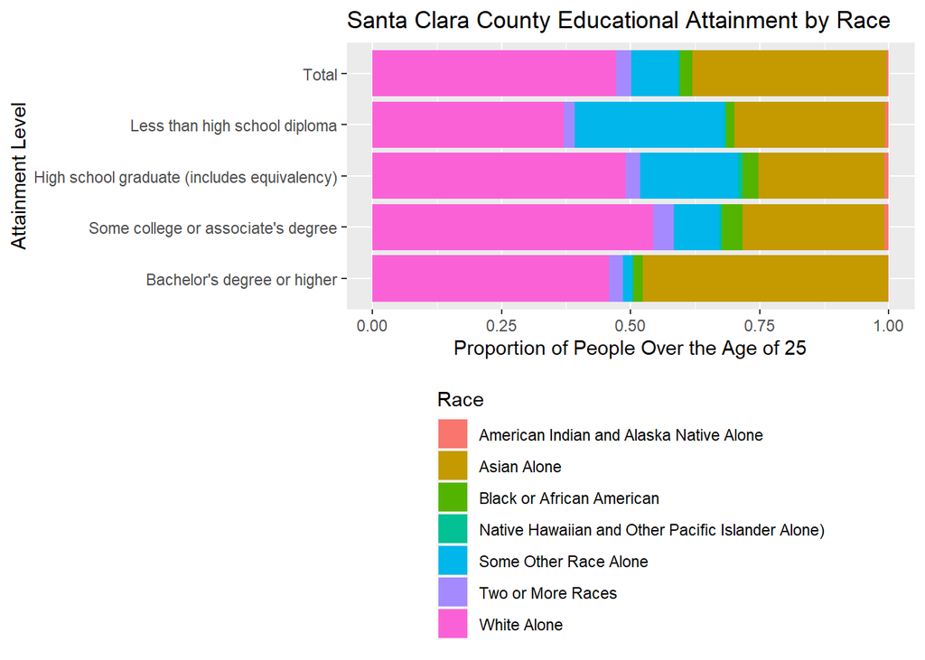

```r
scc_educ_attain %>%
  group_by(educational_attainment, race) %>%
  summarize(estimate = sum(estimate)) %>%
  rbind(scc_race_total) %>%
  ggplot() +
  geom_bar(
    aes(
      x = educational_attainment %>%
        factor(
          levels =
            rev(c("Total", scc_educ_attain$educational_attainment[1:4]))),
      y = estimate,
      fill = race
    ),
    stat = "identity",
    position = "fill"
  ) +
  labs(
    x = "Attainment Level",
    y = "Proportion of People Over the Age of 25",
    title = "Santa Clara County Educational Attainment by Race",
    fill = "Race"
  ) +
  coord_flip() +
  theme(
    legend.position = "bottom",
    legend.direction = "vertical"
  )
```

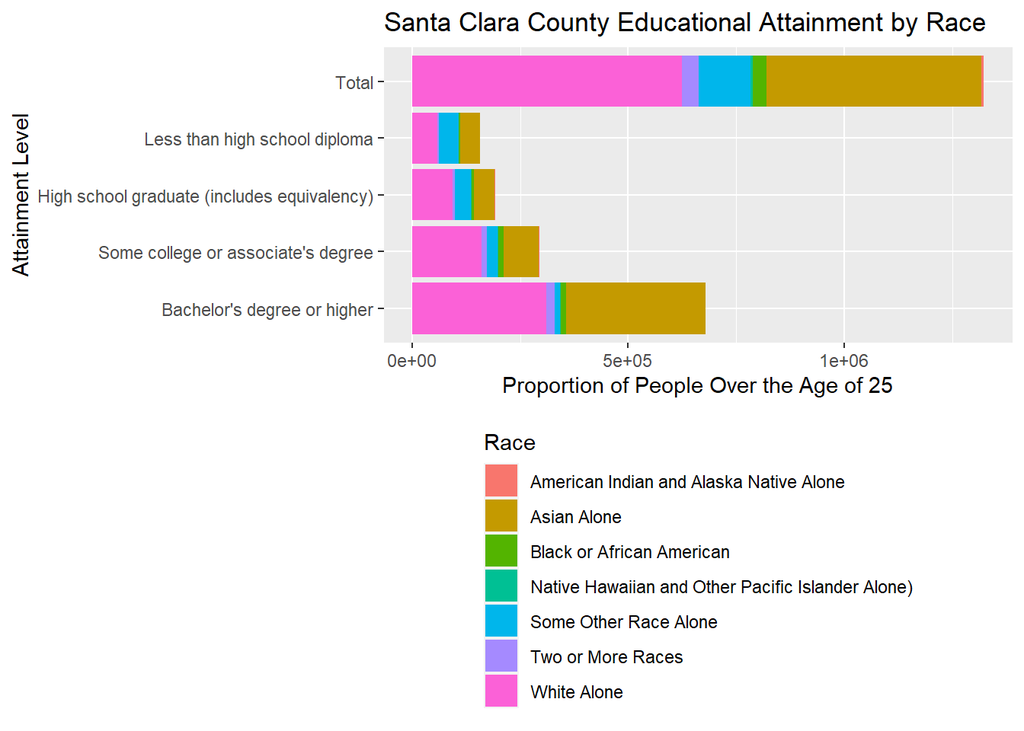

```r
scc_educ_attain %>%
  group_by(educational_attainment, race) %>%
  summarize(estimate = sum(estimate)) %>%
  rbind(scc_race_total) %>%
  ggplot() +
  geom_bar(
    aes(
      x = educational_attainment %>%
        factor(
          levels =
            rev(c("Total", scc_educ_attain$educational_attainment[1:4]))),
      y = estimate,
      fill = race
    ),
    stat = "identity",
    position = "stack"
  ) +
  labs(
    x = "Attainment Level",
    y = "Proportion of People Over the Age of 25",
    title = "Santa Clara County Educational Attainment by Race",
    fill = "Race"
  ) +
  coord_flip() +
  theme(
    legend.position = "bottom",
    legend.direction = "vertical"
  )
```

```r
non_white_perc <-
  ((sum(scc_race_total$estimate[1:6]) /
      sum(scc_race_total$estimate))*100) %>% round()
less_hs_race <-
  scc_educ_attain %>%
  filter(educational_attainment == "Less than high school diploma") %>%
  group_by(race) %>%
  summarize(estimate = sum(estimate))

non_white_less_hs_perc <-
  ((sum(less_hs_race$estimate[1:6]) /
      sum(less_hs_race$estimate))*100) %>% round()

non_white_less_hs_likelihood_than_expected <-
  (((non_white_less_hs_perc / non_white_perc) - 1) * 100) %>% round()
```

Q: is there disproportionate education attainment by race in Santa Clara County?  
A: yes. Non-white population (over 25 yrs old) makes up 53% of the county, so if educational attainment were race blind, then we would expect to see 53% of non-white people in each educational attainment level. However, non-white people actually make up 63% of the “less than high school diploma” educational attainment level. This means that non_white people in Santa Clara County are 19% more likely to have an educational attainment level of “less than high school diploma” than we would expect.

```r
ca_pums <- get_pums(
  variables = c(
    "PUMA",
    "ACCESS",
    "SCHG"
  ),
  state = "CA",
  year = 2018,
  survey = "acs1",
  recode = T
)

saveRDS(ca_pums, "ca_pums.rds")
```

```r
k_12_students <-
  scc_pums %>%
  filter(as.numeric(SCHG) %in% c(2:14)) %>%
  filter(!(ACCESS_label == "N/A (GQ/vacant)")) %>%
  select(c(ACCESS, SCHG, SCHG_label, ACCESS_label, PWGTP, PUMA)) %>%
  mutate(
    has_internet = ifelse(
      as.numeric(ACCESS) %in% c(1,2),
      PWGTP,
      0
    ),
    no_internet = ifelse(
      as.numeric(ACCESS) == 3,
      PWGTP,
      0
    )
  )

total_num_k_12 = sum(k_12_students$PWGTP)
num_has_internet = sum(k_12_students$has_internet)
num_no_internet = sum(k_12_students$no_internet)
perc_has_internet <- ((num_has_internet/total_num_k_12)*100) %>% round()
perc_no_internet <- ((num_no_internet/total_num_k_12)*100) %>% round()
```

The total number of k-12 students in Santa Clara County is 310,656. The number of these students with access to internet is 302,268. The number without access to internet is 8388. This makes 97% with access to internet and 3% without. My assumption is that the PWGTP represents population/number of people. The data shows in Santa Clara County, 97% of people will not have any problems with remote learning in 2020.

```r
k_12_students_pumas <-
  k_12_students %>%
  group_by(PUMA) %>%
  summarize(
    has_internet = sum(has_internet),
    no_internet = sum(no_internet),
    PWGTP = sum(PWGTP)
  ) %>%
  mutate(
    perc_has_internet = has_internet/PWGTP*100
  ) %>%
  left_join(
    scc_pumas %>%
      select(PUMACE10),
    by = c("PUMA" = "PUMACE10")
    ) %>%
  st_as_sf()

pums_pal <- colorNumeric(
  palette = "Oranges",
  domain = k_12_students_pumas$perc_has_internet
)

leaflet() %>%
  addTiles() %>%
  addPolygons(
    data = k_12_students_pumas,
    fillColor = ~pums_pal(perc_has_internet),
    color = "white",
    opacity = 0.5,
    fillOpacity = 0.5,
    weight = 1,
    label = ~paste0(
      round(perc_has_internet),
      "% of individuals in K-12 schools have internet"
    ),
    highlightOptions = highlightOptions(
      weight = 2,
      opacity = 1
    )
  ) %>%
  addLegend(
    data = k_12_students_pumas,
    pal = pums_pal,
    values = ~perc_has_internet,
    title = "% individuals in<br>K-12 schools that have internet<br>in Santa Clara County"
  )
```

[interactive chart not shown]

```r
acs_vars_2019_1yr <-
  listCensusMetadata(
    name = "2019/acs/acs1",
    type = "variables"
  )

scc_mobility_current_19 <-
  getCensus(
    name = "acs/acs1",
    vintage = 2019,
    region = "county:085",
    regionin = "state:06",
    vars = c("group(B07009)")
  ) %>%
  select(!c(GEO_ID,state,NAME) & !ends_with(c("EA","MA","M"))) %>%
  pivot_longer(
    ends_with("E"),
    names_to = "variable",
    values_to = "estimate"
  ) %>%
  left_join(
    acs_vars_2019_1yr %>%
      select(name, label),
    by = c("variable" = "name")
  ) %>%
  separate(
    label,
    into = c(NA,NA,"mobility", "educational_attainment"),
    sep = "!!"
  ) %>%
  mutate(
    mobility = ifelse(
      mobility %in% c("Same house 1 year ago:", "Moved within same county:"),
      "Here since last year",
      "Inflow"
    )
  ) %>%
  filter(
    !(is.na(mobility)) &
      !(is.na(educational_attainment))
    ) %>%
  group_by(mobility, educational_attainment) %>%
  summarize(estimate = sum(estimate))
```

```r
scc_mobility_lastyear_19 <-
  getCensus(
    name = "acs/acs1",
    vintage = 2019,
    region = "county:085",
    regionin = "state:06",
    vars = c("group(B07409)")
  ) %>%
  select(!c(GEO_ID,state,NAME) & !ends_with(c("EA","MA","M"))) %>%
  pivot_longer(
    ends_with("E"),
    names_to = "variable",
    values_to = "estimate"
  ) %>%
  left_join(
    acs_vars_2019_1yr %>%
      select(name, label),
    by = c("variable" = "name")
  ) %>%
  separate(
    label,
    into = c(NA,NA,"mobility", "educational_attainment"),
    sep = "!!"
  ) %>%
  mutate(
    mobility = ifelse(
      mobility %in% c("Same house:", "Moved within same county:"),
      "Here since last year",
      "Outflow"
    )
  ) %>%
  filter(
    !(is.na(mobility)) &
      !(is.na(educational_attainment))
    ) %>%
  group_by(mobility, educational_attainment) %>%
  summarize(estimate = sum(estimate))
```

B07009 - GEOGRAPHICAL MOBILITY IN THE PAST YEAR BY EDUCATIONAL ATTAINMENT FOR CURRENT RESIDENCE IN THE UNITED STATES B07409 - GEOGRAPHICAL MOBILITY IN THE PAST YEAR BY EDUCATIONAL ATTAINMENT FOR RESIDENCE 1 YEAR AGO IN THE UNITED STATES

```r
scc_mobility_current_18 <-
  getCensus(
    name = "acs/acs1",
    vintage = 2018,
    region = "county:085",
    regionin = "state:06",
    vars = c("group(B07009)")
  ) %>%
  select(!c(GEO_ID,state,NAME) & !ends_with(c("EA","MA","M"))) %>%
  pivot_longer(
    ends_with("E"),
    names_to = "variable",
    values_to = "estimate"
  ) %>%
  left_join(
    acs_vars_2019_1yr %>%
      select(name, label),
    by = c("variable" = "name")
  ) %>%
  select(-variable) %>%
  separate(
    label,
    into = c(NA,NA,"mobility","educational_attainment"),
    sep = "!!"
  ) %>%
  mutate(
    mobility = "Here last year"
  ) %>%
  filter(
    !(is.na(mobility)) &
      !(is.na(educational_attainment))
    ) %>%
  group_by(mobility, educational_attainment) %>%
  summarize(estimate = sum(estimate))
```

```r
scc_flows_19 <-
  rbind(
    scc_mobility_current_18,
    scc_mobility_lastyear_19 %>%
      filter(mobility == "Outflow"),
    scc_mobility_current_19 %>%
      filter(mobility == "Inflow"),
    scc_mobility_current_19 %>%
      group_by(educational_attainment) %>%
      summarize(estimate = sum(estimate)) %>%
      mutate(mobility = "Here this year")
  ) %>%
  pivot_wider(
    names_from = mobility,
    values_from = estimate
  ) %>%
  mutate(
    `External net` = Inflow - Outflow,
    `Internal net` = `Here this year` - `Here last year` - `External net`,
    `Educational attainment` = educational_attainment %>% factor(levels = c(
      "Less than high school graduate",
      "High school graduate (includes equivalency)",
      "Some college or associate's degree",
      "Bachelor's degree",
      "Graduate or professional degree"
    ))
  ) %>%
  select(
    `Educational attainment`,
    `Internal net`,
    `External net`,
    `Here last year`,
    `Here this year`,
    Outflow,
    Inflow
  ) %>%
  arrange(`Educational attainment`)

scc_flows_19
```

| Educational attainment | Internal net | External net | Here last year | Here this year | Outflow | Inflow |
| --- | --- | --- | --- | --- | --- | --- |
| Less than high school graduate | 3780 | -180 | 145290 | 148890 | 4696 | 4516 |
| High school graduate (includes equivalency) | 56 | 1123 | 184686 | 185865 | 6712 | 7835 |
| Some college or associate's degree | 119 | -3394 | 293946 | 290671 | 11687 | 8293 |
| Bachelor's degree | -4379 | -236 | 383232 | 378617 | 23263 | 23027 |
| Graduate or professional degree | -6143 | 10166 | 342615 | 346638 | 17414 | 27580 |

Internal net generally shows educational mobility within the Santa Clara County. External net generally shows migration into/out of Santa Clara County. Looking at internal net, it looks like there’s a large decrease in amount of people getting bachelor’s or graduate/professional degrees with a large increase in “less than high school graduate.” This implies less high schoolers going to college and less college students going to graduate school. However, looking at external net, there’s a super large increase in graduate or professional degree, which I would attribute to startups, companies, or universities (SCU or stanford) hiring or bringing in professionals.